# Predict Bike Sharing Demand with AutoGluon Template

## Project: Predict Bike Sharing Demand with AutoGluon

This notebook is a template with each step that you need to complete for the project.

Please fill in your code where there are explicit `?` markers in the notebook. You are welcome to add more cells and code as you see fit.

Once you have completed all the code implementations, please export your notebook as a HTML file so the reviews can view your code. Make sure you have all outputs correctly outputted.

`File-> Export Notebook As... -> Export Notebook as HTML`

There is a writeup to complete as well after all code implememtation is done. Please answer all questions and attach the necessary tables and charts. You can complete the writeup in either markdown or PDF.

Completing the code template and writeup template will cover all of the rubric points for this project.

The rubric contains "Stand Out Suggestions" for enhancing the project beyond the minimum requirements. The stand out suggestions are optional. If you decide to pursue the "stand out suggestions", you can include the code in this notebook and also discuss the results in the writeup file.

## Step 1: Create an account with Kaggle

### Create Kaggle Account and download API key

Below is example of steps to get the API username and key. Each student will have their own username and key.

1. Open account settings.

2. Scroll down to API and click Create New API Token.

3. Open up `kaggle.json` and use the username and key.


## Step 2: Download the Kaggle dataset using the kaggle python library

### Open up Sagemaker Studio and use starter template

1. Notebook should be using a `ml.t3.medium` instance (2 vCPU + 4 GiB)
2. Notebook should be using kernal: `Python 3 (MXNet 1.8 Python 3.7 CPU Optimized)`

### Install packages

```python
!pip install -U pip
!pip install -U setuptools wheel
!pip install -U "mxnet<2.0.0" bokeh==2.0.1
```

[output not shown]

```python
!pip install autogluon --no-cache-dir
# Without --no-cache-dir, smaller aws instances may have trouble installing
```

[output not shown]

[output cut: 75 more lines]

[output not shown]

### Setup Kaggle API Key

```python
# create the .kaggle directory and an empty kaggle.json file
!mkdir -p /root/.kaggle
!touch /root/.kaggle/kaggle.json
!chmod 600 /root/.kaggle/kaggle.json
```

```python
!pip install python-dotenv
```

```
  Using cached python_dotenv-0.21.0-py3-none-any.whl (18 kB)
WARNING: Running pip as the 'root' user can result in broken permissions and conflicting behaviour with the system package manager. It is recommended to use a virtual environment instead: https://pip.pypa.io/warnings/venv
```

```python
# Fill in your user name and key from creating the kaggle account and API token file

import json
from dotenv import dotenv_values

CONFIG = dotenv_values('.env')

kaggle_username = CONFIG['KAGGLE_USERNAME']
kaggle_key = CONFIG['KAGGLE_KEY']

# Save API token the kaggle.json file
with open("/root/.kaggle/kaggle.json", "w") as f:
    f.write(json.dumps({"username": kaggle_username, "key": kaggle_key}))
```

### Download and explore dataset

### Go to the bike sharing demand competition and agree to the terms

```python
!pip install kaggle
```

```
  Using cached kaggle-1.5.12-py3-none-any.whl
  Using cached python_slugify-7.0.0-py2.py3-none-any.whl (9.4 kB)
WARNING: Running pip as the 'root' user can result in broken permissions and conflicting behaviour with the system package manager. It is recommended to use a virtual environment instead: https://pip.pypa.io/warnings/venv
```

```python
# Download the dataset, it will be in a .zip file so you'll need to unzip it as well.
! kaggle competitions download -c bike-sharing-demand
# If you already downloaded it you can use the -o command to overwrite the file
!unzip -o bike-sharing-demand.zip
```

```
bike-sharing-demand.zip: Skipping, found more recently modified local copy (use --force to force download)
Archive:  bike-sharing-demand.zip
  inflating: sampleSubmission.csv
  inflating: test.csv
  inflating: train.csv
```

```python
import pandas as pd
from autogluon.tabular import TabularPredictor
```

```python
# Create the train dataset in pandas by reading the csv
# Set the parsing of the datetime column so you can use some of the `dt` features in pandas later
df_train = pd.read_csv('train.csv', parse_dates=['datetime'])
df_train.head()
```

|  | datetime | season | holiday | workingday | weather | temp | atemp | humidity | windspeed | casual | registered | count |
| --- | --- | --- | --- | --- | --- | --- | --- | --- | --- | --- | --- | --- |
| 0 | 2011-01-01 00:00:00 | 1 | 0 | 0 | 1 | 9.84 | 14.395 | 81 | 0.0 | 3 | 13 | 16 |
| 1 | 2011-01-01 01:00:00 | 1 | 0 | 0 | 1 | 9.02 | 13.635 | 80 | 0.0 | 8 | 32 | 40 |
| 2 | 2011-01-01 02:00:00 | 1 | 0 | 0 | 1 | 9.02 | 13.635 | 80 | 0.0 | 5 | 27 | 32 |
| 3 | 2011-01-01 03:00:00 | 1 | 0 | 0 | 1 | 9.84 | 14.395 | 75 | 0.0 | 3 | 10 | 13 |
| 4 | 2011-01-01 04:00:00 | 1 | 0 | 0 | 1 | 9.84 | 14.395 | 75 | 0.0 | 0 | 1 | 1 |

```python
df_train.shape
```

```
(10886, 12)
```

```python
# Create the test pandas dataframe in pandas by reading the csv, remember to parse the datetime!
df_test = pd.read_csv('test.csv',parse_dates=['datetime'])
df_test.head()
```

|  | datetime | season | holiday | workingday | weather | temp | atemp | humidity | windspeed |
| --- | --- | --- | --- | --- | --- | --- | --- | --- | --- |
| 0 | 2011-01-20 00:00:00 | 1 | 0 | 1 | 1 | 10.66 | 11.365 | 56 | 26.0027 |
| 1 | 2011-01-20 01:00:00 | 1 | 0 | 1 | 1 | 10.66 | 13.635 | 56 | 0.0000 |
| 2 | 2011-01-20 02:00:00 | 1 | 0 | 1 | 1 | 10.66 | 13.635 | 56 | 0.0000 |
| 3 | 2011-01-20 03:00:00 | 1 | 0 | 1 | 1 | 10.66 | 12.880 | 56 | 11.0014 |
| 4 | 2011-01-20 04:00:00 | 1 | 0 | 1 | 1 | 10.66 | 12.880 | 56 | 11.0014 |

```python
df_test.shape
```

```
(6493, 9)
```

```python
# Same thing as train and test dataset
submission =  pd.read_csv('sampleSubmission.csv')
submission.head()
```

|  | datetime | count |
| --- | --- | --- |
| 0 | 2011-01-20 00:00:00 | 0 |
| 1 | 2011-01-20 01:00:00 | 0 |
| 2 | 2011-01-20 02:00:00 | 0 |
| 3 | 2011-01-20 03:00:00 | 0 |
| 4 | 2011-01-20 04:00:00 | 0 |

## Step 3: Train a model using AutoGluon’s Tabular Prediction

Requirements:

- We are prediting `count`, so it is the label we are setting.
- Ignore `casual` and `registered` columns as they are also not present in the test dataset.
- Use the `root_mean_squared_error` as the metric to use for evaluation.
- Set a time limit of 10 minutes (600 seconds).
- Use the preset `best_quality` to focus on creating the best model.

```python
train1 = df_train.drop(columns=['casual', 'registered'])
```

```python
train1.head()
```

|  | datetime | season | holiday | workingday | weather | temp | atemp | humidity | windspeed | count |
| --- | --- | --- | --- | --- | --- | --- | --- | --- | --- | --- |
| 0 | 2011-01-01 00:00:00 | 1 | 0 | 0 | 1 | 9.84 | 14.395 | 81 | 0.0 | 16 |
| 1 | 2011-01-01 01:00:00 | 1 | 0 | 0 | 1 | 9.02 | 13.635 | 80 | 0.0 | 40 |
| 2 | 2011-01-01 02:00:00 | 1 | 0 | 0 | 1 | 9.02 | 13.635 | 80 | 0.0 | 32 |
| 3 | 2011-01-01 03:00:00 | 1 | 0 | 0 | 1 | 9.84 | 14.395 | 75 | 0.0 | 13 |
| 4 | 2011-01-01 04:00:00 | 1 | 0 | 0 | 1 | 9.84 | 14.395 | 75 | 0.0 | 1 |

```python
from sklearn.model_selection import train_test_split
train1, val1 = train_test_split(train1, test_size= 0.1, random_state=32 )
```

```python
predictor = TabularPredictor(label='count', eval_metric='root_mean_squared_error').fit(train_data=train1,
                                                time_limit=600,
                                                presets= 'best_quality')
```

```
No path specified. Models will be saved in: "AutogluonModels/ag-20230103_111242/"
Presets specified: ['best_quality']
Stack configuration (auto_stack=True): num_stack_levels=1, num_bag_folds=8, num_bag_sets=20
Beginning AutoGluon training ... Time limit = 600s
AutoGluon will save models to "AutogluonModels/ag-20230103_111242/"
AutoGluon Version:  0.6.1
Python Version:     3.8.10
Operating System:   Linux
Platform Machine:   x86_64
Platform Version:   #1 SMP Wed Oct 26 20:36:53 UTC 2022
Train Data Rows:    9797
Train Data Columns: 9
Label Column: count
Preprocessing data ...
AutoGluon infers your prediction problem is: 'regression' (because dtype of label-column == int and many unique label-values observed).
	Label info (max, min, mean, stddev): (977, 1, 191.8324, 181.48836)
	If 'regression' is not the correct problem_type, please manually specify the problem_type parameter during predictor init (You may specify problem_type as one of: ['binary', 'multiclass', 'regression'])
Using Feature Generators to preprocess the data ...
Fitting AutoMLPipelineFeatureGenerator...
	Available Memory:                    3028.35 MB
	Train Data (Original)  Memory Usage: 0.71 MB (0.0% of available memory)
	Inferring data type of each feature based on column values. Set feature_metadata_in to manually specify special dtypes of the features.
	Stage 1 Generators:
		Fitting AsTypeFeatureGenerator...
			Note: Converting 2 features to boolean dtype as they only contain 2 unique values.
	Stage 2 Generators:
		Fitting FillNaFeatureGenerator...
	Stage 3 Generators:
		Fitting IdentityFeatureGenerator...
		Fitting DatetimeFeatureGenerator...
	Stage 4 Generators:
		Fitting DropUniqueFeatureGenerator...
	Types of features in original data (raw dtype, special dtypes):
		('datetime', []) : 1 | ['datetime']
		('float', [])    : 3 | ['temp', 'atemp', 'windspeed']
		('int', [])      : 5 | ['season', 'holiday', 'workingday', 'weather', 'humidity']
	Types of features in processed data (raw dtype, special dtypes):
		('float', [])                : 3 | ['temp', 'atemp', 'windspeed']
		('int', [])                  : 3 | ['season', 'weather', 'humidity']
		('int', ['bool'])            : 2 | ['holiday', 'workingday']
```

[output cut: 86 more lines]

```
	-65.0558	 = Validation score   (-root_mean_squared_error)
	7.55s	 = Training   runtime
	0.55s	 = Validation runtime
Fitting model: NeuralNetFastAI_BAG_L2 ... Training model for up to 6.89s of the 6.87s of remaining time.
	Fitting 8 child models (S1F1 - S1F8) | Fitting with ParallelLocalFoldFittingStrategy
	-107.775	 = Validation score   (-root_mean_squared_error)
	26.32s	 = Training   runtime
	0.4s	 = Validation runtime
Completed 1/20 k-fold bagging repeats ...
Fitting model: WeightedEnsemble_L3 ... Training model for up to 360.0s of the -22.6s of remaining time.
	-63.7915	 = Validation score   (-root_mean_squared_error)
	0.32s	 = Training   runtime
	0.0s	 = Validation runtime
AutoGluon training complete, total runtime = 623.11s ... Best model: "WeightedEnsemble_L3"
TabularPredictor saved. To load, use: predictor = TabularPredictor.load("AutogluonModels/ag-20230103_111242/")
```

### Review AutoGluon's training run with ranking of models that did the best.

```python
predictor.fit_summary()
```

```
*** Summary of fit() ***
Estimated performance of each model:
                     model   score_val  pred_time_val    fit_time  pred_time_val_marginal  fit_time_marginal  stack_level  can_infer  fit_order
0      WeightedEnsemble_L3  -63.791487      10.756341  494.908243                0.000669           0.320490            3       True         18
1   RandomForestMSE_BAG_L2  -64.301013       9.985727  405.956941                0.561404          25.923227            2       True         14
2     ExtraTreesMSE_BAG_L2  -65.055801       9.977440  387.582162                0.553117           7.548448            2       True         16
3          LightGBM_BAG_L2  -65.745387       9.594113  401.432568                0.169790          21.398854            2       True         13
4          CatBoost_BAG_L2  -66.065786       9.471361  439.717224                0.047038          59.683510            2       True         15
5        LightGBMXT_BAG_L2  -70.307037      12.447144  423.989331                3.022820          43.955618            2       True         12
6    KNeighborsDist_BAG_L1  -89.176118       0.041738    0.016991                0.041738           0.016991            1       True          2
7      WeightedEnsemble_L2  -89.176118       0.042416    0.528413                0.000679           0.511421            2       True         11
8    KNeighborsUnif_BAG_L1 -106.538094       0.047076    0.120931                0.047076           0.120931            1       True          1
9   NeuralNetFastAI_BAG_L2 -107.774961       9.823465  406.354973                0.399141          26.321259            2       True         17
10  RandomForestMSE_BAG_L1 -119.173450       0.570518    9.055790                0.570518           9.055790            1       True          5
11    ExtraTreesMSE_BAG_L1 -125.995914       0.525174    4.309122                0.525174           4.309122            1       True          7
12         CatBoost_BAG_L1 -131.328538       0.086275  163.209638                0.086275         163.209638            1       True          6
13    LightGBMLarge_BAG_L1 -131.395073       0.395754   21.469450                0.395754          21.469450            1       True         10
14       LightGBMXT_BAG_L1 -131.990394       5.840187   57.527486                5.840187          57.527486            1       True          3
15         LightGBM_BAG_L1 -132.181664       1.123287   23.875048                1.123287          23.875048            1       True          4
16          XGBoost_BAG_L1 -132.350591       0.481968   20.598536                0.481968          20.598536            1       True          9
17  NeuralNetFastAI_BAG_L1 -136.351066       0.312347   79.850721                0.312347          79.850721            1       True          8
Number of models trained: 18
Types of models trained:
{'StackerEnsembleModel_XT', 'StackerEnsembleModel_KNN', 'StackerEnsembleModel_RF', 'StackerEnsembleModel_NNFastAiTabular', 'StackerEnsembleModel_XGBoost', 'StackerEnsembleModel_CatBoost', 'WeightedEnsembleModel', 'StackerEnsembleModel_LGB'}
Bagging used: True  (with 8 folds)
Multi-layer stack-ensembling used: True  (with 3 levels)
Feature Metadata (Processed):
(raw dtype, special dtypes):
('float', [])                : 3 | ['temp', 'atemp', 'windspeed']
('int', [])                  : 3 | ['season', 'weather', 'humidity']
('int', ['bool'])            : 2 | ['holiday', 'workingday']
('int', ['datetime_as_int']) : 5 | ['datetime', 'datetime.year', 'datetime.month', 'datetime.day', 'datetime.dayofweek']
Plot summary of models saved to file: AutogluonModels/ag-20230103_111242/SummaryOfModels.html
*** End of fit() summary ***
```

[output not shown]

[output cut: 175 more lines]

```
 3          13
 4          15
 5          12
 6           2
 7          11
 8           1
 9          17
 10          5
 11          7
 12          6
 13         10
 14          3
 15          4
 16          9
 17          8  }
```

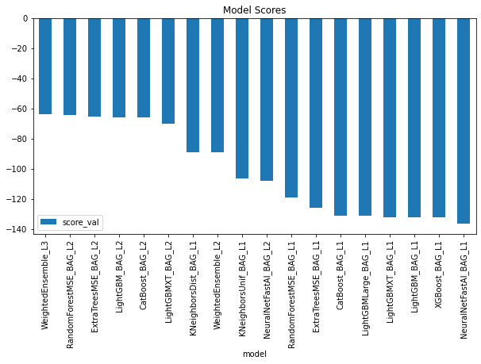

```python
#model's `score_val` in a bar chart to compare performance
import matplotlib.pyplot as plt


predictor.leaderboard(silent=True).plot(kind="bar",
                                        x="model",
                                        y="score_val",
                                        figsize=(10,5),
                                        title="Model Scores");
```

```python
performance = predictor.evaluate(val1)   # model performance on val set
```

```
Evaluation: root_mean_squared_error on test data: -65.70141582317879
	Note: Scores are always higher_is_better. This metric score can be multiplied by -1 to get the metric value.
Evaluations on test data:
{
    "root_mean_squared_error": -65.70141582317879,
    "mean_squared_error": -4316.676041170248,
    "mean_absolute_error": -40.7277638599126,
    "r2": 0.8637648005567908,
    "pearsonr": 0.9294873539684775,
    "median_absolute_error": -22.53955078125
}
```

### Create predictions from test dataset

```python
predictions = predictor.predict(df_test)
predictions.head()
```

```
0    29.112467
1    39.351299
2    52.116562
3    53.940048
4    54.696800
Name: count, dtype: float32
```

#### NOTE: Kaggle will reject the submission if we don't set everything to be > 0.

```python
# Describe the `predictions` series to see if there are any negative values
predictions.describe()
```

```
count    6493.000000
mean      115.684853
std       102.280807
min         3.985307
25%        21.382456
50%        83.258629
75%       190.575027
max       491.224884
Name: count, dtype: float64
```

```python
# How many negative values do we have?
sum(predictions < 0)
```

```
0
```

No negative predicitons. But if they are, They will be set to zero.

```python
# Set them to zero
predictions[predictions < 0] = 0
```

### Set predictions to submission dataframe, save, and submit

```python
submission["count"] =  predictions
submission.to_csv("submission.csv", index=False)
```

```python
!kaggle competitions submit -c bike-sharing-demand -f submission.csv -m "first raw submission"
```

```
Successfully submitted to Bike Sharing Demand
```

#### View submission via the command line or in the web browser under the competition's page - `My Submissions`

```python
!kaggle competitions submissions -c bike-sharing-demand | tail -n +1 | head -n 20
```

```
fileName                     date                 description                        status    publicScore  privateScore
---------------------------  -------------------  ---------------------------------  --------  -----------  ------------
submission.csv               2023-01-03 11:31:07  first raw submission               complete  1.79728      1.79728
submission_new_hpo.csv       2022-12-31 14:56:10  new features with hyperparameters  complete  1.83235      1.83235
submission_new_hpo.csv       2022-12-31 14:10:24  new features with hyperparameters  complete  1.24540      1.24540
submission_new_hpo.csv       2022-12-31 13:34:17  new features with hyperparameters  complete  0.62032      0.62032
submission_new_hpo.csv       2022-12-31 13:20:20  new features with hyperparameters  complete  1.24540      1.24540
submission_new_hpo.csv       2022-12-31 13:18:52  new features with hyperparameters  error
submission_new_hpo.csv       2022-12-31 12:02:43  new features with hyperparameters  error
submission_new_features.csv  2022-12-31 11:28:31  new features                       complete  0.77978      0.77978
submission.csv               2022-12-31 11:15:53  first raw submission               complete  1.80182      1.80182
submission_new_hpo.csv       2022-12-29 14:07:37  new features with hyperparameters  complete  0.49030      0.49030
submission_new_features.csv  2022-12-29 14:04:51  new features                       complete  0.49030      0.49030
submission.csv               2022-12-29 14:02:14  first raw submission               complete  1.80853      1.80853
submission_new_hpo.csv       2022-12-28 12:49:18  new features with hyperparameters  complete  0.91769      0.91769
submission_new_hpo.csv       2022-12-28 12:32:02  new features with hyperparameters  complete  0.61944      0.61944
submission_new_hpo.csv       2022-12-28 12:01:36  new features with hyperparameters  error
submission_new_hpo.csv       2022-12-28 11:48:50  new features with hyperparameters  complete  0.51509      0.51509
submission_new_hpo.csv       2022-12-28 11:30:54  new features with hyperparameters  complete  0.51509      0.51509
submission_new_features.csv  2022-12-28 11:14:53  new features                       complete  0.64057      0.64057
```

#### Initial score of 1.80

## Step 4: Exploratory Data Analysis and Creating an additional feature

- Any additional feature will do, but a great suggestion would be to separate out the datetime into hour, day, or month parts.

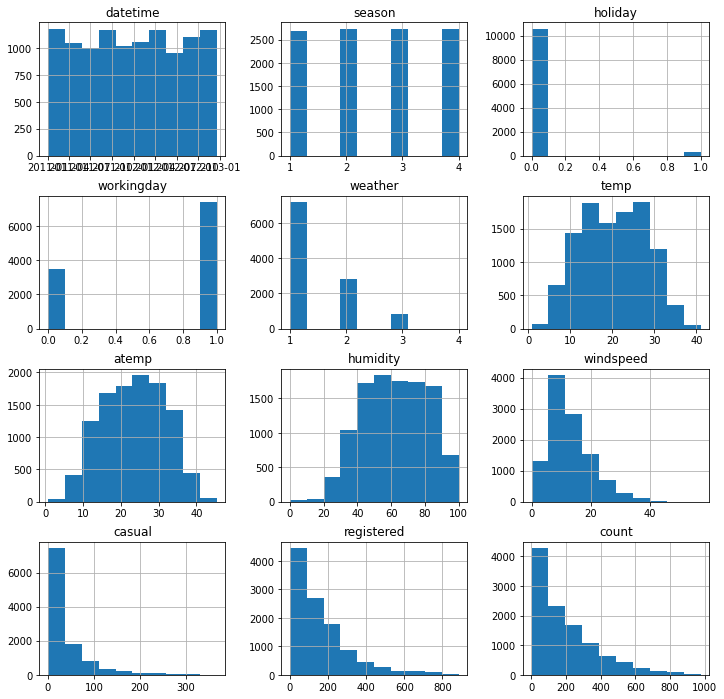

```python
# Create a histogram of all features to show the distribution of each one relative to the data. This is part of the exploritory data analysis
df_train.hist(figsize=(12,12));
```

```python
# Already read datetime as datetime object
```

```python
df_train.info()   # changed datetime data type
```

```
<class 'pandas.core.frame.DataFrame'>
RangeIndex: 10886 entries, 0 to 10885
Data columns (total 12 columns):
 #   Column      Non-Null Count  Dtype
---  ------      --------------  -----
 0   datetime    10886 non-null  datetime64[ns]
 1   season      10886 non-null  int64
 2   holiday     10886 non-null  int64
 3   workingday  10886 non-null  int64
 4   weather     10886 non-null  int64
 5   temp        10886 non-null  float64
 6   atemp       10886 non-null  float64
 7   humidity    10886 non-null  int64
 8   windspeed   10886 non-null  float64
 9   casual      10886 non-null  int64
 10  registered  10886 non-null  int64
 11  count       10886 non-null  int64
dtypes: datetime64[ns](1), float64(3), int64(8)
memory usage: 1020.7 KB
```

```python
df_train.head()
```

|  | datetime | season | holiday | workingday | weather | temp | atemp | humidity | windspeed | casual | registered | count |
| --- | --- | --- | --- | --- | --- | --- | --- | --- | --- | --- | --- | --- |
| 0 | 2011-01-01 00:00:00 | 1 | 0 | 0 | 1 | 9.84 | 14.395 | 81 | 0.0 | 3 | 13 | 16 |
| 1 | 2011-01-01 01:00:00 | 1 | 0 | 0 | 1 | 9.02 | 13.635 | 80 | 0.0 | 8 | 32 | 40 |
| 2 | 2011-01-01 02:00:00 | 1 | 0 | 0 | 1 | 9.02 | 13.635 | 80 | 0.0 | 5 | 27 | 32 |
| 3 | 2011-01-01 03:00:00 | 1 | 0 | 0 | 1 | 9.84 | 14.395 | 75 | 0.0 | 3 | 10 | 13 |
| 4 | 2011-01-01 04:00:00 | 1 | 0 | 0 | 1 | 9.84 | 14.395 | 75 | 0.0 | 0 | 1 | 1 |

```python
# Creating a new feature temp_diff, difference between actual and percieved temperature
df_train['temp_diff'] = df_train['temp']-df_train['atemp']
df_test['temp_diff'] = df_test['temp']-df_test['atemp']
(df_train['temp_diff']).describe()
```

```
count    10886.000000
mean        -3.424224
std          1.566612
min         -8.045000
25%         -4.055000
50%         -3.680000
75%         -2.745000
max         23.140000
Name: temp_diff, dtype: float64
```

```python
# We can see that temp and atemp are  highly correlated 0.98
```

```python
df_train[['count', 'temp_diff', 'atemp', 'temp']].corr()
```

|  | count | temp_diff | atemp | temp |
| --- | --- | --- | --- | --- |
| count | 1.000000 | -0.146716 | 0.389784 | 0.394454 |
| temp_diff | -0.146716 | 1.000000 | -0.510840 | -0.354556 |
| atemp | 0.389784 | -0.510840 | 1.000000 | 0.984948 |
| temp | 0.394454 | -0.354556 | 0.984948 | 1.000000 |

```python
df_train[['temp', 'atemp']].corr()
```

|  | temp | atemp |
| --- | --- | --- |
| temp | 1.000000 | 0.984948 |
| atemp | 0.984948 | 1.000000 |

### temp and atemp are highly correlated. dropping one of them to reduce multicolinearity

```python
# create a new feature, extracting year, month, day, weekday and hour

#train data
df_train["year"] = df_train.datetime.dt.year
df_train["month"] = df_train.datetime.dt.month
df_train["day"] = df_train.datetime.dt.day
df_train['hour'] = df_train.datetime.dt.hour
df_train['weekday'] = df_train.datetime.dt.weekday

#test data
df_test['year'] = df_test.datetime.dt.year
df_test['month'] = df_test.datetime.dt.month
df_test['day'] = df_test.datetime.dt.day
df_test['hour'] = df_test.datetime.dt.hour
df_test['weekday'] = df_test.datetime.dt.weekday
```

```python
#checking unique years in data
print('years in train data',df_train['year'].unique())
print('years in test data', df_test['year'].unique())
```

```
years in train data [2011 2012]
years in test data [2011 2012]
```

## Make category types for these so models know they are not just numbers

- AutoGluon originally sees these as ints, but in reality they are int representations of a category.
- Setting the dtype to category will classify these as categories in AutoGluon.

```python
# setting season and weather to categories

#train data
df_train["season"] =  df_train["season"].astype('category')
df_train["weather"] = df_train["weather"].astype('category')

#test data
df_test["season"] = df_test["season"].astype('category')
df_test["weather"] = df_test["season"].astype('category')
```

```python
# One-Hot Encoding

#train data
weather_one_hot_train = pd.get_dummies(df_train.weather, prefix="weather")
season_one_hot_train = pd.get_dummies(df_train.season, prefix="season")

#test data
weather_one_hot_test = pd.get_dummies(df_test.weather, prefix="weather")
season_one_hot_test = pd.get_dummies(df_test.season, prefix="season")
```

```python
# adding codes to data

#train
df_train[weather_one_hot_train.columns.tolist()] = weather_one_hot_train
df_train[season_one_hot_train.columns.tolist()] = season_one_hot_train

#test
df_test[weather_one_hot_train.columns.tolist()] = weather_one_hot_test
df_test[season_one_hot_train.columns.tolist()] = season_one_hot_test
```

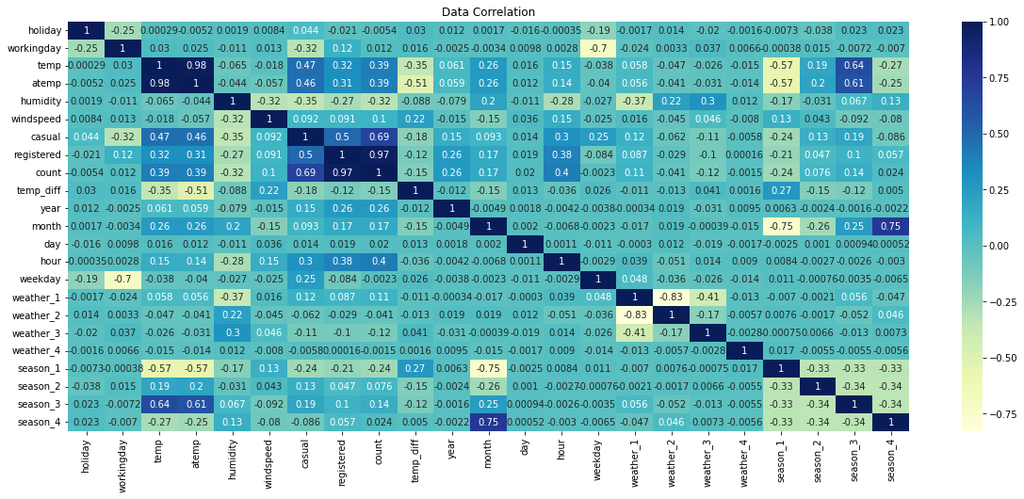

```python
# correlation Heatmap
import seaborn as sns
import matplotlib.pyplot as plt


plt.figure(figsize=(20,8))
sns.heatmap(df_train.corr(), cmap="YlGnBu", annot=True)
plt.title("Data Correlation");
```

```python
df_train.corr()
```

|  | holiday | workingday | temp | atemp | humidity | windspeed | casual | registered | count | temp_diff | ... | hour | weekday | weather_1 | weather_2 | weather_3 | weather_4 | season_1 | season_2 | season_3 | season_4 |
| --- | --- | --- | --- | --- | --- | --- | --- | --- | --- | --- | --- | --- | --- | --- | --- | --- | --- | --- | --- | --- | --- |
| holiday | 1.000000 | -0.250491 | 0.000295 | -0.005215 | 0.001929 | 0.008409 | 0.043799 | -0.020956 | -0.005393 | 0.029675 | ... | -0.000354 | -0.191832 | -0.001708 | 0.013868 | -0.019514 | -0.001644 | -0.007336 | -0.038250 | 0.022790 | 0.022751 |
| workingday | -0.250491 | 1.000000 | 0.029966 | 0.024660 | -0.010880 | 0.013373 | -0.319111 | 0.119460 | 0.011594 | 0.015634 | ... | 0.002780 | -0.704267 | -0.024078 | 0.003324 | 0.036643 | 0.006562 | -0.000379 | 0.014620 | -0.007194 | -0.007048 |
| temp | 0.000295 | 0.029966 | 1.000000 | 0.984948 | -0.064949 | -0.017852 | 0.467097 | 0.318571 | 0.394454 | -0.354556 | ... | 0.145430 | -0.038466 | 0.058430 | -0.046925 | -0.025715 | -0.014800 | -0.565655 | 0.192661 | 0.635975 | -0.266220 |
| atemp | -0.005215 | 0.024660 | 0.984948 | 1.000000 | -0.043536 | -0.057473 | 0.462067 | 0.314635 | 0.389784 | -0.510840 | ... | 0.140343 | -0.040235 | 0.055825 | -0.040792 | -0.031154 | -0.013901 | -0.569082 | 0.204421 | 0.607090 | -0.245690 |
| humidity | 0.001929 | -0.010880 | -0.064949 | -0.043536 | 1.000000 | -0.318607 | -0.348187 | -0.265458 | -0.317371 | -0.087518 | ... | -0.278011 | -0.026507 | -0.374837 | 0.222398 | 0.295894 | 0.012010 | -0.166208 | -0.031095 | 0.067308 | 0.129018 |
| windspeed | 0.008409 | 0.013373 | -0.017852 | -0.057473 | -0.318607 | 1.000000 | 0.092276 | 0.091052 | 0.101369 | 0.222113 | ... | 0.146631 | -0.024804 | 0.015920 | -0.045016 | 0.045597 | -0.007979 | 0.128819 | 0.042991 | -0.091521 | -0.079535 |
| casual | 0.043799 | -0.319111 | 0.467097 | 0.462067 | -0.348187 | 0.092276 | 1.000000 | 0.497250 | 0.690414 | -0.176432 | ... | 0.302045 | 0.246959 | 0.119728 | -0.062184 | -0.108853 | -0.005760 | -0.235222 | 0.132405 | 0.187726 | -0.086258 |
| registered | -0.020956 | 0.119460 | 0.318571 | 0.314635 | -0.265458 | 0.091052 | 0.497250 | 1.000000 | 0.970948 | -0.117599 | ... | 0.380540 | -0.084427 | 0.086621 | -0.028997 | -0.104936 | 0.000155 | -0.207278 | 0.046969 | 0.102142 | 0.056961 |
| count | -0.005393 | 0.011594 | 0.394454 | 0.389784 | -0.317371 | 0.101369 | 0.690414 | 0.970948 | 1.000000 | -0.146716 | ... | 0.400601 | -0.002283 | 0.105246 | -0.041329 | -0.117519 | -0.001459 | -0.237704 | 0.075681 | 0.136942 | 0.023704 |
| temp_diff | 0.029675 | 0.015634 | -0.354556 | -0.510840 | -0.087518 | 0.222113 | -0.176432 | -0.117599 | -0.146716 | 1.000000 | ... | -0.035886 | 0.026340 | -0.011383 | -0.012717 | 0.040636 | 0.001586 | 0.265154 | -0.147611 | -0.121021 | 0.005011 |
| year | 0.012021 | -0.002482 | 0.061226 | 0.058540 | -0.078606 | -0.015221 | 0.145241 | 0.264265 | 0.260403 | -0.012162 | ... | -0.004234 | -0.003785 | -0.000339 | 0.019064 | -0.030774 | 0.009548 | 0.006315 | -0.002446 | -0.001598 | -0.002234 |
| month | 0.001731 | -0.003394 | 0.257589 | 0.264173 | 0.204537 | -0.150192 | 0.092722 | 0.169451 | 0.166862 | -0.147918 | ... | -0.006818 | -0.002266 | -0.017101 | 0.019029 | -0.000392 | -0.015366 | -0.750291 | -0.255581 | 0.248354 | 0.753087 |
| day | -0.015877 | 0.009829 | 0.015551 | 0.011866 | -0.011335 | 0.036157 | 0.014109 | 0.019111 | 0.019826 | 0.013150 | ... | 0.001132 | -0.011070 | -0.000301 | 0.012006 | -0.018953 | -0.001737 | -0.002491 | 0.001019 | 0.000941 | 0.000516 |
| hour | -0.000354 | 0.002780 | 0.145430 | 0.140343 | -0.278011 | 0.146631 | 0.302045 | 0.380540 | 0.400601 | -0.035886 | ... | 1.000000 | -0.002925 | 0.038791 | -0.050671 | 0.014030 | 0.008951 | 0.008357 | -0.002733 | -0.002611 | -0.002964 |
| weekday | -0.191832 | -0.704267 | -0.038466 | -0.040235 | -0.026507 | -0.024804 | 0.246959 | -0.084427 | -0.002283 | 0.026340 | ... | -0.002925 | 1.000000 | 0.048353 | -0.035776 | -0.026177 | -0.014412 | 0.010789 | -0.000757 | -0.003505 | -0.006464 |
| weather_1 | -0.001708 | -0.024078 | 0.058430 | 0.055825 | -0.374837 | 0.015920 | 0.119728 | 0.086621 | 0.105246 | -0.011383 | ... | 0.038791 | 0.048353 | 1.000000 | -0.827798 | -0.408402 | -0.013374 | -0.006996 | -0.002057 | 0.055660 | -0.046642 |
| weather_2 | 0.013868 | 0.003324 | -0.046925 | -0.040792 | 0.222398 | -0.045016 | -0.062184 | -0.028997 | -0.041329 | -0.012717 | ... | -0.050671 | -0.035776 | -0.827798 | 1.000000 | -0.173644 | -0.005686 | 0.007644 | -0.001687 | -0.051895 | 0.045976 |
| weather_3 | -0.019514 | 0.036643 | -0.025715 | -0.031154 | 0.295894 | 0.045597 | -0.108853 | -0.104936 | -0.117519 | 0.040636 | ... | 0.014030 | -0.026177 | -0.408402 | -0.173644 | 1.000000 | -0.002805 | -0.000750 | 0.006556 | -0.013089 | 0.007278 |
| weather_4 | -0.001644 | 0.006562 | -0.014800 | -0.013901 | 0.012010 | -0.007979 | -0.005760 | 0.000155 | -0.001459 | 0.001586 | ... | 0.008951 | -0.014412 | -0.013374 | -0.005686 | -0.002805 | 1.000000 | 0.016747 | -0.005549 | -0.005549 | -0.005551 |
| season_1 | -0.007336 | -0.000379 | -0.565655 | -0.569082 | -0.166208 | 0.128819 | -0.235222 | -0.207278 | -0.237704 | 0.265154 | ... | 0.008357 | 0.010789 | -0.006996 | 0.007644 | -0.000750 | 0.016747 | 1.000000 | -0.331365 | -0.331365 | -0.331446 |
| season_2 | -0.038250 | 0.014620 | 0.192661 | 0.204421 | -0.031095 | 0.042991 | 0.132405 | 0.046969 | 0.075681 | -0.147611 | ... | -0.002733 | -0.000757 | -0.002057 | -0.001687 | 0.006556 | -0.005549 | -0.331365 | 1.000000 | -0.335214 | -0.335296 |
| season_3 | 0.022790 | -0.007194 | 0.635975 | 0.607090 | 0.067308 | -0.091521 | 0.187726 | 0.102142 | 0.136942 | -0.121021 | ... | -0.002611 | -0.003505 | 0.055660 | -0.051895 | -0.013089 | -0.005549 | -0.331365 | -0.335214 | 1.000000 | -0.335296 |
| season_4 | 0.022751 | -0.007048 | -0.266220 | -0.245690 | 0.129018 | -0.079535 | -0.086258 | 0.056961 | 0.023704 | 0.005011 | ... | -0.002964 | -0.006464 | -0.046642 | 0.045976 | 0.007278 | -0.005551 | -0.331446 | -0.335296 | -0.335296 | 1.000000 |

23 rows × 23 columns

```python
# View are new feature
df_train.head()
```

|  | datetime | season | holiday | workingday | weather | temp | atemp | humidity | windspeed | casual | ... | hour | weekday | weather_1 | weather_2 | weather_3 | weather_4 | season_1 | season_2 | season_3 | season_4 |
| --- | --- | --- | --- | --- | --- | --- | --- | --- | --- | --- | --- | --- | --- | --- | --- | --- | --- | --- | --- | --- | --- |
| 0 | 2011-01-01 00:00:00 | 1 | 0 | 0 | 1 | 9.84 | 14.395 | 81 | 0.0 | 3 | ... | 0 | 5 | 1 | 0 | 0 | 0 | 1 | 0 | 0 | 0 |
| 1 | 2011-01-01 01:00:00 | 1 | 0 | 0 | 1 | 9.02 | 13.635 | 80 | 0.0 | 8 | ... | 1 | 5 | 1 | 0 | 0 | 0 | 1 | 0 | 0 | 0 |
| 2 | 2011-01-01 02:00:00 | 1 | 0 | 0 | 1 | 9.02 | 13.635 | 80 | 0.0 | 5 | ... | 2 | 5 | 1 | 0 | 0 | 0 | 1 | 0 | 0 | 0 |
| 3 | 2011-01-01 03:00:00 | 1 | 0 | 0 | 1 | 9.84 | 14.395 | 75 | 0.0 | 3 | ... | 3 | 5 | 1 | 0 | 0 | 0 | 1 | 0 | 0 | 0 |
| 4 | 2011-01-01 04:00:00 | 1 | 0 | 0 | 1 | 9.84 | 14.395 | 75 | 0.0 | 0 | ... | 4 | 5 | 1 | 0 | 0 | 0 | 1 | 0 | 0 | 0 |

5 rows × 26 columns

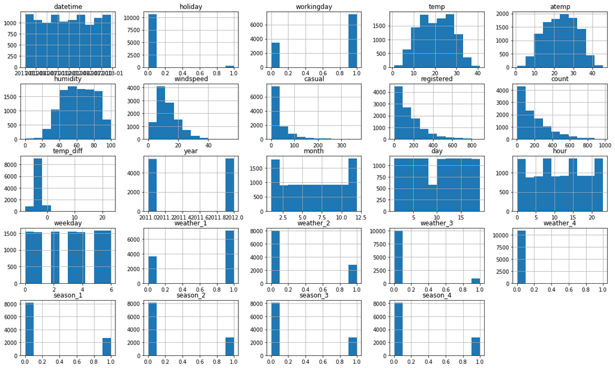

```python
# View histogram of all features again now with the hour feature
df_train.hist(figsize=(20,12));
```

## Step 5: Rerun the model with the same settings as before, just with more features

```python
train2, val2= train_test_split(df_train, test_size=0.1, random_state=32)
```

```python
train2.head()
```

|  | datetime | season | holiday | workingday | weather | temp | atemp | humidity | windspeed | casual | ... | hour | weekday | weather_1 | weather_2 | weather_3 | weather_4 | season_1 | season_2 | season_3 | season_4 |
| --- | --- | --- | --- | --- | --- | --- | --- | --- | --- | --- | --- | --- | --- | --- | --- | --- | --- | --- | --- | --- | --- |
| 3977 | 2011-09-16 18:00:00 | 3 | 0 | 1 | 2 | 21.32 | 25.000 | 52 | 11.0014 | 55 | ... | 18 | 4 | 0 | 1 | 0 | 0 | 0 | 0 | 1 | 0 |
| 5087 | 2011-12-06 01:00:00 | 4 | 0 | 1 | 2 | 18.86 | 22.725 | 88 | 19.9995 | 2 | ... | 1 | 1 | 0 | 1 | 0 | 0 | 0 | 0 | 0 | 1 |
| 2758 | 2011-07-03 20:00:00 | 3 | 0 | 0 | 3 | 27.06 | 30.305 | 83 | 0.0000 | 83 | ... | 20 | 6 | 0 | 0 | 1 | 0 | 0 | 0 | 1 | 0 |
| 4861 | 2011-11-15 15:00:00 | 4 | 0 | 1 | 2 | 22.14 | 25.760 | 60 | 8.9981 | 36 | ... | 15 | 1 | 0 | 1 | 0 | 0 | 0 | 0 | 0 | 1 |
| 9080 | 2012-09-01 17:00:00 | 3 | 0 | 0 | 2 | 33.62 | 38.635 | 52 | 0.0000 | 205 | ... | 17 | 5 | 0 | 1 | 0 | 0 | 0 | 0 | 1 | 0 |

5 rows × 26 columns

```python
print('data shape Before feature engineering: ',train1.shape)
print('data shape After feature engineering: ',train2.shape)
```

```
data shape Before feature engineering:  (9797, 10)
data shape After feature engineering:  (9797, 26)
```

```python
# 6 columns will be egnored during training frpm train2
```

```python
ignore_columns = [ 'datetime','atemp', 'registered', 'casual', 'weather', 'season']
```

```python
predictor_new_features = (TabularPredictor( label='count',
                                            eval_metric='root_mean_squared_error',
                                            problem_type='regression',
                                            learner_kwargs={"ignored_columns": ignore_columns}
                                          ).fit( train_data = train2,
                                                 time_limit=600,
                                                 presets= 'best_quality'))
```

```
No path specified. Models will be saved in: "AutogluonModels/ag-20230103_115112/"
Presets specified: ['best_quality']
Stack configuration (auto_stack=True): num_stack_levels=1, num_bag_folds=8, num_bag_sets=20
Beginning AutoGluon training ... Time limit = 600s
AutoGluon will save models to "AutogluonModels/ag-20230103_115112/"
AutoGluon Version:  0.6.1
Python Version:     3.8.10
Operating System:   Linux
Platform Machine:   x86_64
Platform Version:   #1 SMP Wed Oct 26 20:36:53 UTC 2022
Train Data Rows:    9797
Train Data Columns: 25
Label Column: count
Preprocessing data ...
Using Feature Generators to preprocess the data ...
Dropping user-specified ignored columns: ['datetime', 'atemp', 'registered', 'casual', 'weather', 'season']
Fitting AutoMLPipelineFeatureGenerator...
	Available Memory:                    1939.89 MB
	Train Data (Original)  Memory Usage: 0.94 MB (0.0% of available memory)
	Inferring data type of each feature based on column values. Set feature_metadata_in to manually specify special dtypes of the features.
	Stage 1 Generators:
		Fitting AsTypeFeatureGenerator...
			Note: Converting 11 features to boolean dtype as they only contain 2 unique values.
	Stage 2 Generators:
		Fitting FillNaFeatureGenerator...
	Stage 3 Generators:
		Fitting IdentityFeatureGenerator...
	Stage 4 Generators:
		Fitting DropUniqueFeatureGenerator...
	Types of features in original data (raw dtype, special dtypes):
		('float', []) :  3 | ['temp', 'windspeed', 'temp_diff']
		('int', [])   : 16 | ['holiday', 'workingday', 'humidity', 'year', 'month', ...]
	Types of features in processed data (raw dtype, special dtypes):
		('float', [])     :  3 | ['temp', 'windspeed', 'temp_diff']
		('int', [])       :  5 | ['humidity', 'month', 'day', 'hour', 'weekday']
		('int', ['bool']) : 11 | ['holiday', 'workingday', 'year', 'weather_1', 'weather_2', ...]
	0.1s = Fit runtime
	19 features in original data used to generate 19 features in processed data.
	Train Data (Processed) Memory Usage: 0.73 MB (0.0% of available memory)
Data preprocessing and feature engineering runtime = 0.11s ...
```

[output cut: 67 more lines]

```
	-33.3628	 = Validation score   (-root_mean_squared_error)
	9.42s	 = Training   runtime
	0.58s	 = Validation runtime
Fitting model: NeuralNetFastAI_BAG_L2 ... Training model for up to 61.84s of the 61.82s of remaining time.
	Fitting 8 child models (S1F1 - S1F8) | Fitting with ParallelLocalFoldFittingStrategy
	-33.8586	 = Validation score   (-root_mean_squared_error)
	69.28s	 = Training   runtime
	0.46s	 = Validation runtime
Completed 1/20 k-fold bagging repeats ...
Fitting model: WeightedEnsemble_L3 ... Training model for up to 360.0s of the -10.8s of remaining time.
	-33.0512	 = Validation score   (-root_mean_squared_error)
	0.35s	 = Training   runtime
	0.0s	 = Validation runtime
AutoGluon training complete, total runtime = 611.33s ... Best model: "WeightedEnsemble_L3"
TabularPredictor saved. To load, use: predictor = TabularPredictor.load("AutogluonModels/ag-20230103_115112/")
```

```python
predictor_new_features.fit_summary(show_plot=True);
```

```
*** Summary of fit() ***
Estimated performance of each model:
                     model   score_val  pred_time_val    fit_time  pred_time_val_marginal  fit_time_marginal  stack_level  can_infer  fit_order
0      WeightedEnsemble_L3  -33.051177      12.803664  532.911643                0.000899           0.352311            3       True         16
1      WeightedEnsemble_L2  -33.211253      10.488555  348.191328                0.000970           0.600559            2       True          9
2          CatBoost_BAG_L2  -33.319962      11.194117  429.051273                0.057987          33.540046            2       True         13
3     ExtraTreesMSE_BAG_L2  -33.362827      11.719494  404.936074                0.583364           9.424847            2       True         14
4          LightGBM_BAG_L2  -33.730571      11.222512  414.580608                0.086382          19.069381            2       True         11
5   NeuralNetFastAI_BAG_L2  -33.858587      11.592576  464.793688                0.456445          69.282461            2       True         15
6   RandomForestMSE_BAG_L2  -33.869158      11.704970  420.311977                0.568839          24.800750            2       True         12
7        LightGBMXT_BAG_L2  -34.459689      11.344992  415.043861                0.208862          19.532634            2       True         10
8          CatBoost_BAG_L1  -34.472187       0.113760  231.775068                0.113760         231.775068            1       True          6
9          LightGBM_BAG_L1  -35.269132       2.936618   36.191699                2.936618          36.191699            1       True          4
10       LightGBMXT_BAG_L1  -35.454738       6.359550   63.723618                6.359550          63.723618            1       True          3
11    ExtraTreesMSE_BAG_L1  -39.809389       0.531458    5.161950                0.531458           5.161950            1       True          7
12  RandomForestMSE_BAG_L1  -40.222436       0.546199   10.738435                0.546199          10.738435            1       True          5
13  NeuralNetFastAI_BAG_L1  -74.557116       0.330835   47.890423                0.330835          47.890423            1       True          8
14   KNeighborsDist_BAG_L1 -115.420869       0.153530    0.015743                0.153530           0.015743            1       True          2
15   KNeighborsUnif_BAG_L1 -120.113588       0.164181    0.014291                0.164181           0.014291            1       True          1
Number of models trained: 16
Types of models trained:
{'StackerEnsembleModel_XT', 'StackerEnsembleModel_KNN', 'StackerEnsembleModel_RF', 'StackerEnsembleModel_NNFastAiTabular', 'StackerEnsembleModel_CatBoost', 'WeightedEnsembleModel', 'StackerEnsembleModel_LGB'}
Bagging used: True  (with 8 folds)
Multi-layer stack-ensembling used: True  (with 3 levels)
Feature Metadata (Processed):
(raw dtype, special dtypes):
('float', [])     :  3 | ['temp', 'windspeed', 'temp_diff']
('int', [])       :  5 | ['humidity', 'month', 'day', 'hour', 'weekday']
('int', ['bool']) : 11 | ['holiday', 'workingday', 'year', 'weather_1', 'weather_2', ...]
Plot summary of models saved to file: AutogluonModels/ag-20230103_115112/SummaryOfModels.html
*** End of fit() summary ***
```

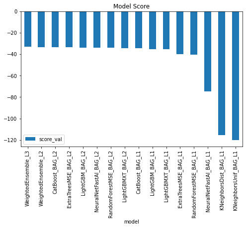

```python
# Output the model's `score_val` in a bar chart to compare performance
predictor_new_features.leaderboard(silent=True).plot(kind="bar", x="model", y="score_val", figsize=(8,5), title='Model Score');
```

```python
# Evaluate the models performance on the val dataset
performance = predictor_new_features.evaluate(val2)
```

```
Evaluation: root_mean_squared_error on test data: -31.940246729458167
	Note: Scores are always higher_is_better. This metric score can be multiplied by -1 to get the metric value.
Evaluations on test data:
{
    "root_mean_squared_error": -31.940246729458167,
    "mean_squared_error": -1020.1793611386632,
    "mean_absolute_error": -19.554405005072322,
    "r2": 0.9678029258144438,
    "pearsonr": 0.9837888639884456,
    "median_absolute_error": -10.6767578125
}
```

```python
train_performance = predictor_new_features.evaluate(train2)
```

```
Evaluation: root_mean_squared_error on test data: -14.705152488446164
	Note: Scores are always higher_is_better. This metric score can be multiplied by -1 to get the metric value.
Evaluations on test data:
{
    "root_mean_squared_error": -14.705152488446164,
    "mean_squared_error": -216.2415097084544,
    "mean_absolute_error": -9.16424836239499,
    "r2": 0.9934342276179533,
    "pearsonr": 0.9967164090319741,
    "median_absolute_error": -5.308185577392578
}
```

```python
#test = df_test.drop(columns=['datetime','atemp', 'weather', 'season'])
```

```python
df_train.info()
```

```
<class 'pandas.core.frame.DataFrame'>
RangeIndex: 10886 entries, 0 to 10885
Data columns (total 26 columns):
 #   Column      Non-Null Count  Dtype
---  ------      --------------  -----
 0   datetime    10886 non-null  datetime64[ns]
 1   season      10886 non-null  category
 2   holiday     10886 non-null  int64
 3   workingday  10886 non-null  int64
 4   weather     10886 non-null  category
 5   temp        10886 non-null  float64
 6   atemp       10886 non-null  float64
 7   humidity    10886 non-null  int64
 8   windspeed   10886 non-null  float64
 9   casual      10886 non-null  int64
```

[output cut: 18 more lines]

```python
df_test.head()
```

|  | datetime | season | holiday | workingday | weather | temp | atemp | humidity | windspeed | temp_diff | ... | hour | weekday | weather_1 | weather_2 | weather_3 | weather_4 | season_1 | season_2 | season_3 | season_4 |
| --- | --- | --- | --- | --- | --- | --- | --- | --- | --- | --- | --- | --- | --- | --- | --- | --- | --- | --- | --- | --- | --- |
| 0 | 2011-01-20 00:00:00 | 1 | 0 | 1 | 1 | 10.66 | 11.365 | 56 | 26.0027 | -0.705 | ... | 0 | 3 | 1 | 0 | 0 | 0 | 1 | 0 | 0 | 0 |
| 1 | 2011-01-20 01:00:00 | 1 | 0 | 1 | 1 | 10.66 | 13.635 | 56 | 0.0000 | -2.975 | ... | 1 | 3 | 1 | 0 | 0 | 0 | 1 | 0 | 0 | 0 |
| 2 | 2011-01-20 02:00:00 | 1 | 0 | 1 | 1 | 10.66 | 13.635 | 56 | 0.0000 | -2.975 | ... | 2 | 3 | 1 | 0 | 0 | 0 | 1 | 0 | 0 | 0 |
| 3 | 2011-01-20 03:00:00 | 1 | 0 | 1 | 1 | 10.66 | 12.880 | 56 | 11.0014 | -2.220 | ... | 3 | 3 | 1 | 0 | 0 | 0 | 1 | 0 | 0 | 0 |
| 4 | 2011-01-20 04:00:00 | 1 | 0 | 1 | 1 | 10.66 | 12.880 | 56 | 11.0014 | -2.220 | ... | 4 | 3 | 1 | 0 | 0 | 0 | 1 | 0 | 0 | 0 |

5 rows × 23 columns

```python
# Remember to set all negative values to zero
pred = predictor_new_features.predict(df_test)
```

```python
pred[pred<0] =0
```

```python
# Same submitting predictions
submission_new_features  = pd.DataFrame()
submission_new_features["datetime"] = submission['datetime']
submission_new_features["count"] = pred
submission_new_features.to_csv("submission_new_features.csv", index=False)
```

```python
!kaggle competitions submit -c bike-sharing-demand -f submission_new_features.csv -m "new features"
```

```
Successfully submitted to Bike Sharing Demand
```

```python
!kaggle competitions submissions -c bike-sharing-demand | tail -n +1 | head -n 10
```

```
fileName                     date                 description                        status    publicScore  privateScore
---------------------------  -------------------  ---------------------------------  --------  -----------  ------------
submission_new_features.csv  2023-01-03 12:30:39  new features                       complete  0.84643      0.84643
submission.csv               2023-01-03 11:31:07  first raw submission               complete  1.79728      1.79728
submission_new_hpo.csv       2022-12-31 14:56:10  new features with hyperparameters  complete  1.83235      1.83235
submission_new_hpo.csv       2022-12-31 14:10:24  new features with hyperparameters  complete  1.24540      1.24540
submission_new_hpo.csv       2022-12-31 13:34:17  new features with hyperparameters  complete  0.62032      0.62032
submission_new_hpo.csv       2022-12-31 13:20:20  new features with hyperparameters  complete  1.24540      1.24540
submission_new_hpo.csv       2022-12-31 13:18:52  new features with hyperparameters  error
submission_new_hpo.csv       2022-12-31 12:02:43  new features with hyperparameters  error
tail: write error: Broken pipe
```

#### New Score of 0.84643

## Step 6: Hyper parameter optimization

- There are many options for hyper parameter optimization.
- Options are to change the AutoGluon higher level parameters or the individual model hyperparameters.
- The hyperparameters of the models themselves that are in AutoGluon. Those need the `hyperparameter` and `hyperparameter_tune_kwargs` arguments.

```python
import numpy as np

hyperparameter_tune_kwargs = { 'num_trials': 5,
                                'scheduler' : 'local',
                               'searcher': 'auto'}

# Hyperpameter Valid str options: [‘default’, ‘light’, ‘very_light’, ‘toy’, ‘multimodal’]
# defult value gave the best result
#cat = {'learning_rate': [0.03, 0.1],'depth': [4, 6, 10],'l2_leaf_reg': [1, 3, 5, 7, 9]}

# did noy spefiy arguments for each model because autosetting willl work better
hyperparameters=  {'CAT': {}, 'XGB': {}, 'FASTAI': {}, 'RF':{}, 'NN_TORCH': {}}
```

```python
predictor_new_hpo = TabularPredictor(label='count',
                                      eval_metric='root_mean_squared_error',
                                      problem_type='regression',
                                      learner_kwargs={"ignored_columns": ignore_columns}
                                     ).fit( train_data = train2,
                                            time_limit=900,
                                            presets= 'best_quality',
                                            auto_stack =True,
                                            refit_full = True,
                                            set_best_to_refit_full=  True,
                                            hyperparameter_tune_kwargs = hyperparameter_tune_kwargs,
                                            hyperparameters=hyperparameters)
```

```
No model was trained during hyperparameter tuning NeuralNetTorch_BAG_L2... Skipping this model.
Completed 1/20 k-fold bagging repeats ...
Fitting model: WeightedEnsemble_L3 ... Training model for up to 360.0s of the 228.66s of remaining time.
	-33.7162	 = Validation score   (-root_mean_squared_error)
	1.13s	 = Training   runtime
	0.0s	 = Validation runtime
AutoGluon training complete, total runtime = 672.66s ... Best model: "WeightedEnsemble_L3"
Fitting model: RandomForest_BAG_L1_FULL | Skipping fit via cloning parent ...
	9.89s	 = Training   runtime
	0.55s	 = Validation runtime
Fitting 1 L1 models ...
Fitting model: CatBoost_BAG_L1/T1_FULL ...
	8.77s	 = Training   runtime
Fitting 1 L1 models ...
Fitting model: NeuralNetFastAI_BAG_L1/4bc27c3a_FULL ...
	Stopping at the best epoch learned earlier - 28.
	9.26s	 = Training   runtime
Fitting 1 L1 models ...
Fitting model: XGBoost_BAG_L1/T1_FULL ...
	1.42s	 = Training   runtime
Fitting 1 L1 models ...
Fitting model: XGBoost_BAG_L1/T2_FULL ...
	1.74s	 = Training   runtime
Fitting model: WeightedEnsemble_L2_FULL | Skipping fit via cloning parent ...
	0.8s	 = Training   runtime
Fitting model: RandomForest_BAG_L2_FULL | Skipping fit via cloning parent ...
	20.85s	 = Training   runtime
	0.58s	 = Validation runtime
Fitting 1 L2 models ...
Fitting model: CatBoost_BAG_L2/T1_FULL ...
	0.96s	 = Training   runtime
Fitting 1 L2 models ...
Fitting model: CatBoost_BAG_L2/T2_FULL ...
	0.45s	 = Training   runtime
Fitting 1 L2 models ...
Fitting model: CatBoost_BAG_L2/T3_FULL ...
	3.5s	 = Training   runtime
Fitting 1 L2 models ...
Fitting model: NeuralNetFastAI_BAG_L2/1ae628f4_FULL ...
	Stopping at the best epoch learned earlier - 25.
	8.3s	 = Training   runtime
Fitting 1 L2 models ...
Fitting model: XGBoost_BAG_L2/T1_FULL ...
	0.17s	 = Training   runtime
Fitting 1 L2 models ...
Fitting model: XGBoost_BAG_L2/T2_FULL ...
	0.22s	 = Training   runtime
Fitting 1 L2 models ...
Fitting model: XGBoost_BAG_L2/T3_FULL ...
	0.94s	 = Training   runtime
Fitting model: WeightedEnsemble_L3_FULL | Skipping fit via cloning parent ...
	1.13s	 = Training   runtime
TabularPredictor saved. To load, use: predictor = TabularPredictor.load("AutogluonModels/ag-20230104_135942/")
```

```python
predictor_new_hpo.fit_summary();
```

```
*** Summary of fit() ***
Estimated performance of each model:
                                   model  score_val  pred_time_val    fit_time  pred_time_val_marginal  fit_time_marginal  stack_level  can_infer  fit_order
0                    WeightedEnsemble_L3 -33.716158       0.002764  491.792926                0.001134           1.129211            3       True         15
1                     CatBoost_BAG_L2/T3 -33.888059       0.000792  325.668832                0.000087          47.497258            2       True         10
2                    WeightedEnsemble_L2 -34.046471       0.001825  278.974259                0.001120           0.802686            2       True          6
3                     CatBoost_BAG_L2/T1 -34.111034       0.000818  309.016511                0.000113          30.844937            2       True          8
4                     CatBoost_BAG_L2/T2 -34.321750       0.000786  302.846354                0.000081          24.674781            2       True          9
5        NeuralNetFastAI_BAG_L2/1ae628f4 -34.374935       0.001205  364.375959                0.000500          86.204385            2       True         11
6                      XGBoost_BAG_L2/T2 -34.491331       0.000828  300.904979                0.000123          22.733406            2       True         13
7                      XGBoost_BAG_L2/T3 -34.836358       0.000787  311.239985                0.000082          33.068412            2       True         14
8                      XGBoost_BAG_L2/T1 -34.846378       0.000830  302.336496                0.000125          24.164923            2       True         12
9                     CatBoost_BAG_L1/T1 -34.855828       0.000116   98.257273                0.000116          98.257273            1       True          2
10                   RandomForest_BAG_L2 -34.870584       0.000849  301.442353                0.000144          23.270780            2       True          7
11                     XGBoost_BAG_L1/T2 -35.816071       0.000114   44.953279                0.000114          44.953279            1       True          5
12                     XGBoost_BAG_L1/T1 -36.261831       0.000122   36.406196                0.000122          36.406196            1       True          4
13                   RandomForest_BAG_L1 -40.222436       0.000215   12.444731                0.000215          12.444731            1       True          1
14       NeuralNetFastAI_BAG_L1/4bc27c3a -47.082826       0.000138   86.110094                0.000138          86.110094            1       True          3
15              RandomForest_BAG_L1_FULL        NaN       0.548861    9.885702                0.548861           9.885702            1       True         16
16                XGBoost_BAG_L2/T3_FULL        NaN            NaN   32.022757                     NaN           0.939045            2       True         29
17                XGBoost_BAG_L2/T2_FULL        NaN            NaN   31.300987                     NaN           0.217275            2       True         28
18                XGBoost_BAG_L2/T1_FULL        NaN            NaN   31.249894                     NaN           0.166183            2       True         27
19                XGBoost_BAG_L1/T2_FULL        NaN            NaN    1.740547                     NaN           1.740547            1       True         20
20                XGBoost_BAG_L1/T1_FULL        NaN            NaN    1.423814                     NaN           1.423814            1       True         19
21              WeightedEnsemble_L3_FULL        NaN            NaN   66.276469                     NaN           1.129211            3       True         30
22              WeightedEnsemble_L2_FULL        NaN            NaN   31.886398                     NaN           0.802686            2       True         21
23              RandomForest_BAG_L2_FULL        NaN            NaN   51.936364                0.578619          20.852652            2       True         22
24  NeuralNetFastAI_BAG_L2/1ae628f4_FULL        NaN            NaN   39.380627                     NaN           8.296916            2       True         26
25  NeuralNetFastAI_BAG_L1/4bc27c3a_FULL        NaN            NaN    9.262922                     NaN           9.262922            1       True         18
26               CatBoost_BAG_L2/T3_FULL        NaN            NaN   34.583935                     NaN           3.500223            2       True         25
27               CatBoost_BAG_L2/T2_FULL        NaN            NaN   31.538125                     NaN           0.454413            2       True         24
28               CatBoost_BAG_L2/T1_FULL        NaN            NaN   32.043054                     NaN           0.959342            2       True         23
29               CatBoost_BAG_L1/T1_FULL        NaN            NaN    8.770727                     NaN           8.770727            1       True         17
Number of models trained: 30
Types of models trained:
{'WeightedEnsembleModel', 'StackerEnsembleModel_RF', 'StackerEnsembleModel_NNFastAiTabular', 'StackerEnsembleModel_XGBoost', 'StackerEnsembleModel_CatBoost'}
Bagging used: True  (with 8 folds)
Multi-layer stack-ensembling used: True  (with 3 levels)
Feature Metadata (Processed):
(raw dtype, special dtypes):
('float', [])     :  3 | ['temp', 'windspeed', 'temp_diff']
('int', [])       :  5 | ['humidity', 'month', 'day', 'hour', 'weekday']
('int', ['bool']) : 11 | ['holiday', 'workingday', 'year', 'weather_1', 'weather_2', ...]
Plot summary of models saved to file: AutogluonModels/ag-20230104_135942/SummaryOfModels.html
*** End of fit() summary ***
```

```python
predictor_new_hpo.fit_summary().keys()
```

[output not shown]

```
dict_keys(['model_types', 'model_performance', 'model_best', 'model_paths', 'model_fit_times', 'model_pred_times', 'num_bag_folds', 'max_stack_level', 'model_hyperparams', 'leaderboard'])
```

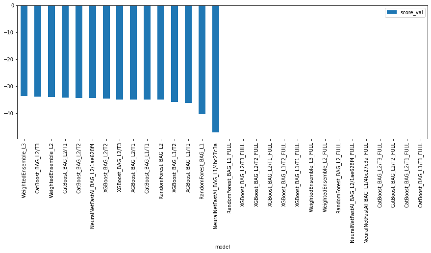

```python
predictor_new_hpo.leaderboard(silent=True).plot(kind="bar", x="model", y="score_val", figsize=(15,5))
```

```python
# Evaluate the models performance on the test dataset
performance = predictor_new_hpo.evaluate(val2)
```

```
Evaluation: root_mean_squared_error on test data: -32.94952677341828
	Note: Scores are always higher_is_better. This metric score can be multiplied by -1 to get the metric value.
Evaluations on test data:
{
    "root_mean_squared_error": -32.94952677341828,
    "mean_squared_error": -1085.671314592208,
    "mean_absolute_error": -20.252181617353244,
    "r2": 0.9657359860544126,
    "pearsonr": 0.9827418415203256,
    "median_absolute_error": -11.422042846679688
}
```

```python
# Remember to set all negative values to zero
pred2 = predictor_new_hpo.predict(df_test)
```

```python
pred2[pred2<0] =0
```

```python
# Same submitting predictions
submission_new_hpo  = pd.DataFrame()
submission_new_hpo["datetime"] = submission['datetime']
submission_new_hpo["count"] = pred2
submission_new_hpo.to_csv("submission_new_hpo.csv", index=False)
```

```python
!kaggle competitions submit -c bike-sharing-demand -f submission_new_hpo.csv -m "new features with hyperparameters"
```

```
Successfully submitted to Bike Sharing Demand
```

```python
!kaggle competitions submissions -c bike-sharing-demand | tail -n +1 | head -n 20
```

```
fileName                     date                 description                        status    publicScore  privateScore
---------------------------  -------------------  ---------------------------------  --------  -----------  ------------
submission_new_hpo.csv       2023-01-04 14:12:59  new features with hyperparameters  complete  2.08258      2.08258
submission_new_hpo.csv       2023-01-04 13:59:06  new features with hyperparameters  complete  0.63731      0.63731
submission_new_hpo.csv       2023-01-04 13:37:54  new features with hyperparameters  complete  1.61821      1.61821
submission_new_hpo.csv       2023-01-04 13:14:11  new features with hyperparameters  complete  0.56834      0.56834
submission_new_hpo.csv       2023-01-03 14:37:51  new features with hyperparameters  complete  0.62930      0.62930
submission_new_hpo.csv       2023-01-03 14:18:41  new features with hyperparameters  complete  0.62911      0.62911
submission_new_hpo.csv       2023-01-03 14:03:05  new features with hyperparameters  complete  0.63079      0.63079
submission_new_hpo.csv       2023-01-03 13:47:17  new features with hyperparameters  complete  0.63090      0.63090
submission_new_features.csv  2023-01-03 12:30:39  new features                       complete  0.84643      0.84643
submission.csv               2023-01-03 11:31:07  first raw submission               complete  1.79728      1.79728
submission_new_hpo.csv       2022-12-31 14:56:10  new features with hyperparameters  complete  1.83235      1.83235
submission_new_hpo.csv       2022-12-31 14:10:24  new features with hyperparameters  complete  1.24540      1.24540
submission_new_hpo.csv       2022-12-31 13:34:17  new features with hyperparameters  complete  0.62032      0.62032
submission_new_hpo.csv       2022-12-31 13:20:20  new features with hyperparameters  complete  1.24540      1.24540
submission_new_hpo.csv       2022-12-31 13:18:52  new features with hyperparameters  error
submission_new_hpo.csv       2022-12-31 12:02:43  new features with hyperparameters  error
submission_new_features.csv  2022-12-31 11:28:31  new features                       complete  0.77978      0.77978
submission.csv               2022-12-31 11:15:53  first raw submission               complete  1.80182      1.80182
tail: write error: Broken pipe
```